# About Me

peter meißner

# About Me

Hallo, I am Peter Meißner, data enthusiast, R-lover, dog walker and full stack computational social scientist - welcome to my personal page.  
I live in the north part of Germany and currently work for [University of Konstanz (IDEP / Ulrich Sieberer)](http://www.polver.uni-konstanz.de/sieberer/forschung/) and [Konvena](http://konvena.de/) as part time freelance consultant doing data and data analytics infrastructure.

For a living in general: I gather data, make it behave, model it and take care that it is presented properly. Some call it data science, I call it getting the job done. My tool set is heavily R-centric but involves everything that comes handy in getting the job done (HTML, Javascript, SQL, PHP, Stata, Latex, Markdown, Word, Excel, SSH, Windows, GNU/Linux, Inkscape, Photoshop, …).

I have special experience in - modelling human behaviour and attitudes - causal inference - dirty data (Texts, Webpages, PDF, Excel) - user interfaces (R-based CLI, GUI for gathering complex data by domain experts) - data based reporting

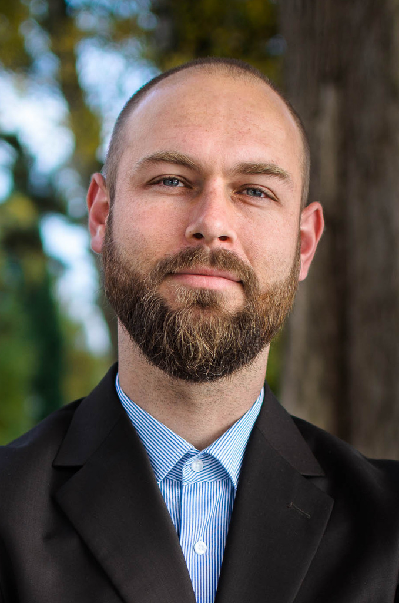